# Metodos de Clasificacion

Leonardo Santella

March 6, 2016

## Becas Crema - Métodos de Clasificación en la mineria de datos

Para el cumplimiento de los objetivos planteados, es necesario la instalacion y carga de ciertas librerias y funciones. También es necesario la asignación manual de una semilla aleatoria, para poder reproducir los resultados dependientes de funciones aleatorias.

```r
#Installing packages
# install.packages(c("party",,"rpart"))
# install.packages("dplyr")
# install.packages("rattle")
# install.packages("FactoMineR")
# install.packages("RColorBrewer")
# install.packages("rpart.plot")
# install.packages("RWeka", dependencies = T)
# install.packages("class")
# install.packages("rJava")

#Library loading
library(party)
library(rpart)
library(dplyr)
library(rattle)
library(FactoMineR)
library(RWeka)
library(rJava)
library(class)



#Functions
proportions <- function(x)
{
  if(x == 0)
    return (prop0)
  if(x == 1)
    return (prop1)
  if(x == 2)
    return (prop2)
  if(x == 3)
    return (prop3)
}

normalize = function(x)
{
  num <- x - min(x)
  denom <- max(x) - min(x)
  return (num/denom)
}

#Set random seed
set.seed(666)
```

## Carga del set de datos y preprocesamiento

A continuación, cargaremos el set de datos y se realizarán actividades de preprocesamiento, con el fin de mejorar los resultados del posterior análisis.

```
## [1] 1 3 2 0
```

```
##      cIdentidad     fNacimiento            sexo          eCivil
##       "integer"        "factor"       "integer"       "integer"
##         escuela        aIngreso        mIngreso          sCurso
##       "integer"       "integer"       "integer"       "integer"
##          tGrado      mInscritas       pAprobado      eficiencia
##       "integer"       "integer"       "numeric"       "numeric"
##      mAprobadas      mRetiradas     mReprobadas     jReprobadas
##       "integer"       "integer"       "integer"        "factor"
##        pRenovar            beca    lProcedencia     lResidencia
##       "integer"       "integer"       "integer"       "integer"
##       tVivienda         pReside     dHabitacion      cDireccion
##       "integer"        "factor"        "factor"        "factor"
##    oSolicitudes      aEconomica      rEconomico      crFamiliar
##        "factor"        "factor"       "integer"       "integer"
##    aResponsable    iActividades          aOtros   gAlimentacion
##       "integer"       "integer"       "integer"       "integer"
##     gTransporte        gMedicos  gOdontologicos       gAlquiler
##       "integer"       "integer"       "integer"       "integer"
##       gEstudios     gPersonales     gRecreacion          gOtros
##       "integer"       "integer"       "integer"       "integer"
##       irMensual         irOtros  grAlimentacion    grTransporte
##       "numeric"       "numeric"       "integer"       "integer"
##       grMedicos grOdontologicos    grEducativos      grVivienda
##       "numeric"        "factor"       "integer"       "integer"
##     grServicios    grCondominio         grOtros          rating
##       "integer"       "numeric"       "numeric"       "integer"
##     sugerencias
##        "factor"
```

```
## 'data.frame':    190 obs. of  53 variables:
##  $ cIdentidad     : int  1 2 3 4 5 6 7 8 9 10 ...
##  $ fNacimiento    : Factor w/ 184 levels "01/01/1994","01/02/1993",..: 97 11 73 23 152 112 168 161 35 54 ...
##  $ sexo           : int  0 0 0 0 0 0 0 0 0 1 ...
##  $ eCivil         : int  2 1 0 0 0 0 0 0 0 0 ...
##  $ escuela        : int  0 0 0 0 0 1 0 1 1 1 ...
##  $ aIngreso       : int  2007 2006 2006 2010 2011 2008 2007 2008 2008 2005 ...
##  $ mIngreso       : int  1 3 3 2 3 3 3 3 0 3 ...
##  $ sCurso         : int  5 6 5 3 6 9 4 8 9 9 ...
##  $ tGrado         : int  0 0 0 0 0 1 0 0 1 1 ...
##  $ mInscritas     : int  1 2 2 3 2 2 2 3 2 2 ...
##  $ pAprobado      : num  10.93 11.31 11.4 6.98 12.52 ...
##  $ eficiencia     : num  0.491 0.669 0.651 0.468 0.833 ...
##  $ mAprobadas     : int  2 11 1 2 3 2 1 1 2 5 ...
##  $ mRetiradas     : int  0 1 1 2 0 0 0 3 0 0 ...
```

[output cut: 39 more lines]

Al principio se pueden observar las características del conjunto de clases (proporciones dentro del data set).

En el preprocesamiento se observaron los tipos de datos de cada columna y se eliminaron las columnas que no eran numéricas.

Se eliminó la primera instancia del set de datos, ya que este era el unico individuo que pertenece a una clase. Si dicho individuo es tomado en cuenta en el diseño de los modelos, podría generar ruido adicional en los resultados.

## Muestreo del set de datos - División en set de entrenamiento y set de prueba

Se aplico un muestreo sin remplazo, con un vector de proporciones con la finalidad de mantener las proporciones orginales en ambos set de datos.

```r
#Sampling
proportions <- apply(as.matrix(data$mIngreso), 1, proportions)
sampling <- sample(nrow(data), nrow(data)*0.8, prob=proportions, replace=F)
train <- data[sampling,]
test <- data[-sampling,]
```

## Árbol de decisión

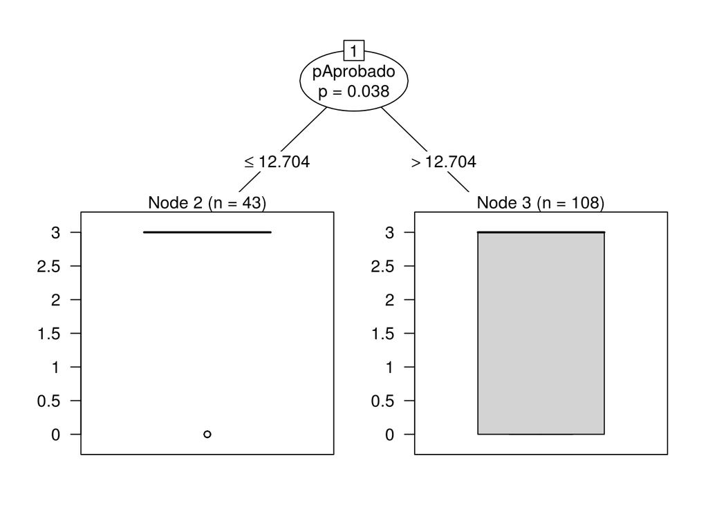

```r
#### Decision tree ####

# Conditional Inference tree
tree <- ctree(formula = mIngreso~.,
              data = train)
#Plot ctree
plot(tree)
```

```r
#Prediction ctree
pred.tree <- predict(tree, test, type="node")

#Confusion Matrix ctree. Measuring prediction performance
perf.tree <- table(test$mIngreso,
                   pred.tree,
                   dnn=c("Actual", "Predicted"))
perf.tree
```

```
##       Predicted
## Actual  2  3
##      0  1 17
##      2  2  6
##      3  5  7
```

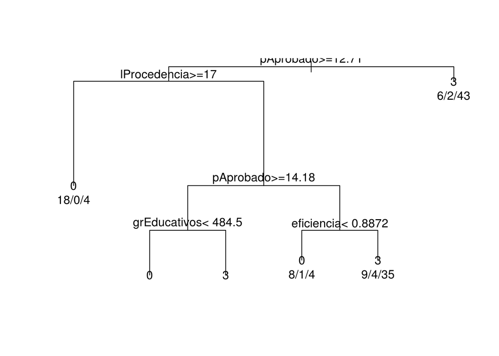

```r
#Recursive Partition tree
tree <- rpart(formula = mIngreso ~ .,
              data = data,
              method = "class",
              control = rpart.control(minsplit = 40,
                                      maxdepth = 4))

#Plot rpart tree
plot(tree)
text(tree,
     use.n = T)
```

```r
#Cofusion Matrix rpart tree. Measuring prediction performance
perf.tree = table(test$mIngreso,
                            predict(tree, newdata = test,type = "class"),
                            dnn = c("Actual", "Predicted"))
perf.tree
```

```
##       Predicted
## Actual  0  2  3
##      0 11  0  7
##      2  2  0  6
##      3  4  0  8
```

```r
#Hit rate
hrate.tree <- (perf.tree[1,1] + perf.tree[2,2] + perf.tree[3,3]) / nrow(test)
hrate.tree <- hrate.tree * 100
hrate.tree
```

```
## [1] 50
```

## K-Vecinos (K-nearest neighbor)

El siguiente modelo que se diseñó, fue realizado a través del método de K-Vecinos. Para la calibración de este modelo fue necesario un preprocesamiento extra para nomalizar las dimensiones.

```r
#### K-Nearest Neighbors ####

knn.train <- train
knn.test <- test
knn.class.train <- knn.train$mIngreso
knn.class.test <- knn.test$mIngreso
knn.test$mIngreso <- NULL
knn.train$mIngreso <- NULL
knn.train <- apply(knn.train,2,normalize)
knn.train <- as.data.frame(knn.train)

#Model and Prediction
knn <- knn(train = knn.train,
           test = knn.test,
           cl = knn.class.train,
           k=15)

#Performance. Confusion matrix
perf.knn <- table(knn.class.test,
                  knn,
                  dnn=c("Actual", "Predicted"))
perf.knn
```

```
##       Predicted
## Actual  0  3
##      0  0 18
##      2  0  8
##      3  0 12
```

```r
#Hit rate. K-Nearest Neighbor
hrate.knn <- (perf.knn[1,1] + perf.knn[2,2]) / nrow(knn.test)
hrate.knn <- hrate.knn * 100
hrate.knn
```

```
## [1] 21.05263
```

## Reglas de Clasificación

Por último, se realizó un modelo de reglas de clasificación. Las reglas fueron generadas a través del algoritmo RIPPER (Repeated Incremental Pruning to Produce Error Reduction)

```r
#### Classification rules ####

#Preprocessing
crules.train <- train
crules.test <- test
crules.train$mIngreso <- as.factor(crules.train$mIngreso)
crules.test$mIngreso <- as.factor(crules.test$mIngreso)

#Model
crules <- JRip(formula = mIngreso ~ .,
               data = crules.train)

#Performance. Confusion Matrix
perf.crules <- table(crules.test$mIngreso,
                     predict(crules,
                             newdata=crules.test),
                     dnn=c("Actual", "Predicted"))
perf.crules
```

```
##       Predicted
## Actual  0  3
##      0  4 14
##      2  0  8
##      3  2 10
```

```r
#Hit rate. CRules
hrate.crules <- (perf.crules[1,1] + perf.crules[2,2]) / nrow(crules.test)
hrate.crules <- hrate.crules * 100
hrate.crules
```

```
## [1] 31.57895
```

## Comparación de modelos

```r
#Comparacion de modelos
hrate <- rbind(hrate.tree, hrate.knn, hrate.crules)
hrate
```

```
##                  [,1]
## hrate.tree   50.00000
## hrate.knn    21.05263
## hrate.crules 31.57895
```